# 3rd Semester Result Analysis

Piyush Jain

2024-12-01

## R Markdown

Hello to anyone, who is reading this. My name is Piyush Jain, and this is my analysis of my class results for the 3rd Semester. I have acquired my data and have properly arranged it in a way that anyone who read this will understand it.  
And if you are interested to check last semesters result analysis,

#### Click Here

In the following table, if any of my friends are reading this they can see there results in the bottom table.

|  | student.name | program | hall_ticket_number | semester_details | PHRM | LAB | CMA | Statistics | DBMS | UHVGS | SGPA | Result |
| --- | --- | --- | --- | --- | --- | --- | --- | --- | --- | --- | --- | --- |
| 1 | SARDARNI GURUPREET KAUR | BBA INFORMATION TECHNOLOGY | 121423408001 | SEMESTER-III(REGULAR) | A+ | O | A+ | O | O | O | 9.63 | PASS |
| 2 | SHLESHA SHARMA | BBA INFORMATION TECHNOLOGY | 121423408002 | SEMESTER-III(REGULAR) | A | A | A | A+ | AB | AB | - | PROMOTED |
| 3 | VEERAMALLY SAIKRISHNA | BBA INFORMATION TECHNOLOGY | 121423408003 | SEMESTER-III(REGULAR) | B | C | A | A | A | A+ | 7.15 | PASS |
| 4 | RAJVEER CHARAN | BBA INFORMATION TECHNOLOGY | 121423408004 | SEMESTER-III(REGULAR) | C | D | B | B+ | A | B | 6.00 | PASS |
| 5 | MAYANK GUPTA | BBA INFORMATION TECHNOLOGY | 121423408005 | SEMESTER-III(REGULAR) | A | A | A | A | A+ | A+ | 8.26 | PASS |
| 6 | PIYUSH JAIN | BBA INFORMATION TECHNOLOGY | 121423408006 | SEMESTER-III(REGULAR) | A | B | A+ | O | O | O | 8.70 | PASS |
| 7 | K VYSHNAVI | BBA INFORMATION TECHNOLOGY | 121423408008 | SEMESTER-III(REGULAR) | A | A | A+ | A+ | O | A+ | 8.81 | PASS |
| 8 | MOHAMMED MUDDASIR MOHIUDDIN | BBA INFORMATION TECHNOLOGY | 121423408009 | SEMESTER-III(REGULAR) | B | C | F | B | AB | AB | - | PROMOTED |
| 9 | ROHITH REDDY VELLANKI | BBA INFORMATION TECHNOLOGY | 121423408010 | SEMESTER-III(REGULAR) | A | D | C | A | A | A | 6.70 | PASS |
| 10 | PARSHAROUTHU SUJITH VERMA | BBA INFORMATION TECHNOLOGY | 121423408011 | SEMESTER-III(REGULAR) | A | B | B | A+ | A | A+ | 7.52 | PASS |

[output cut: 45 more lines]

## Plots of BBA IT Sem 3 Results

In the multiple plots that we have been given below we clearly see the number of students that have passed or failed in the subjects:

Principles of Human Resource Management, Legal Aspects of Business, Cost and Management Accounting, Business Statistics, Database Management Systems, Universal Human Values and Gender Sensitization

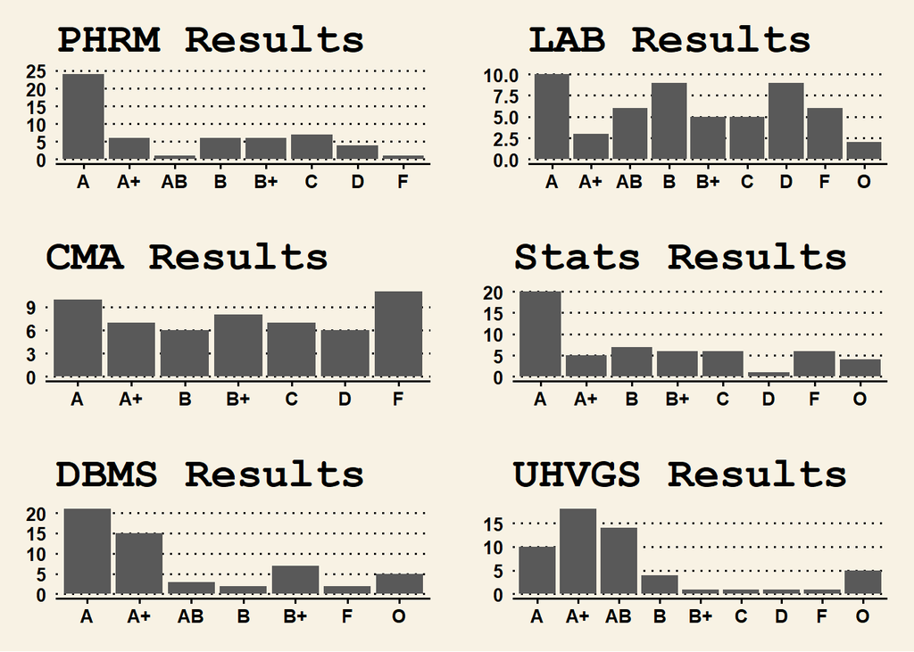

## PHRM Plot

This was an easy subject to score in, many students performed really well in this subject since it is a theoretical subject, but since it is more theoretical no student scored more than A+.

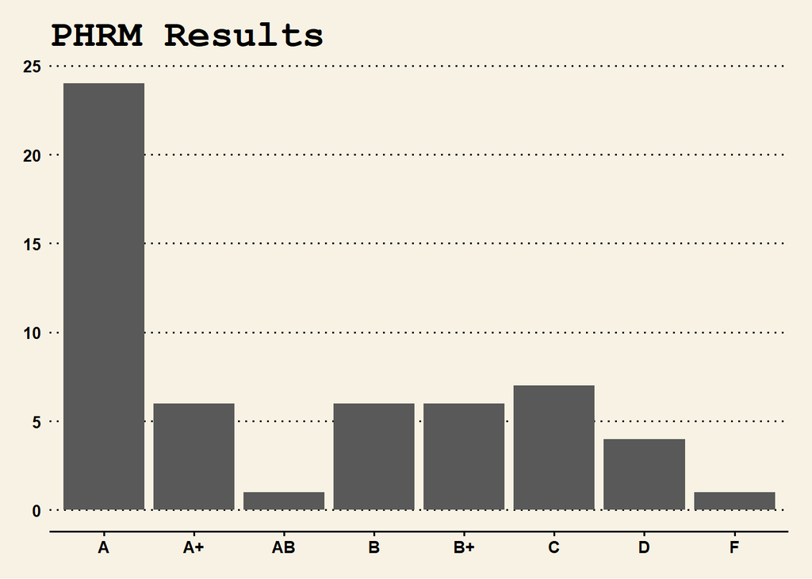

## LAB Plot

Legal Aspects of Business is a mixed bag, you can see it from the graph that 6 students failed and the graph is evenly distributed among all grades.

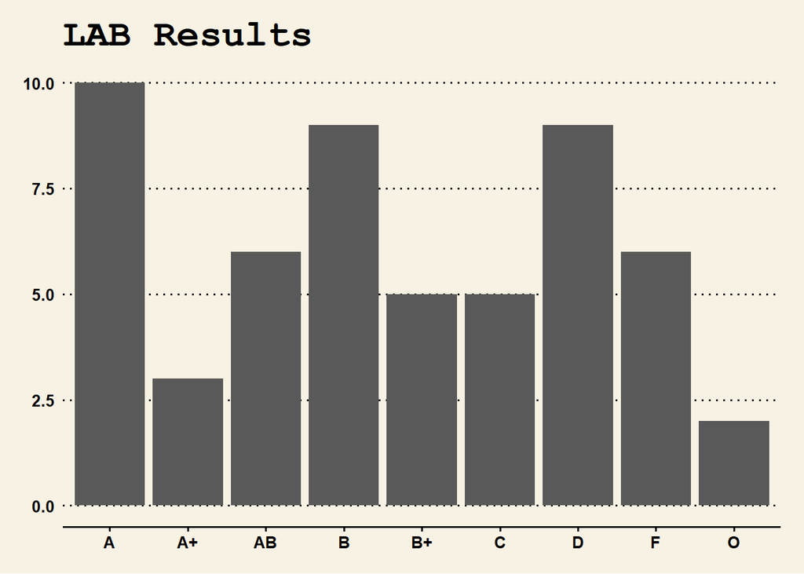

## CMA Plot

This was shocker, Many students failed in this exam due to its practical complexity of the subject, and no one scored an O grade in this exam.

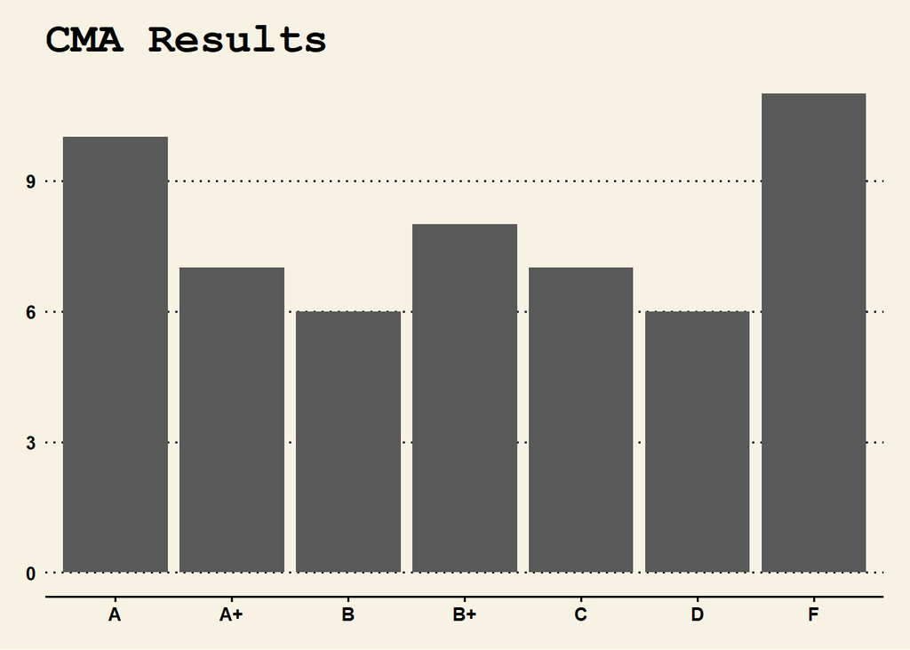

## Statistics Plot

I guess I lost a bet, All jokes aside, I dint think many students would pass this exam due to its maths and “other reasons”, but it is a good sign that many students dint fail in this exam.

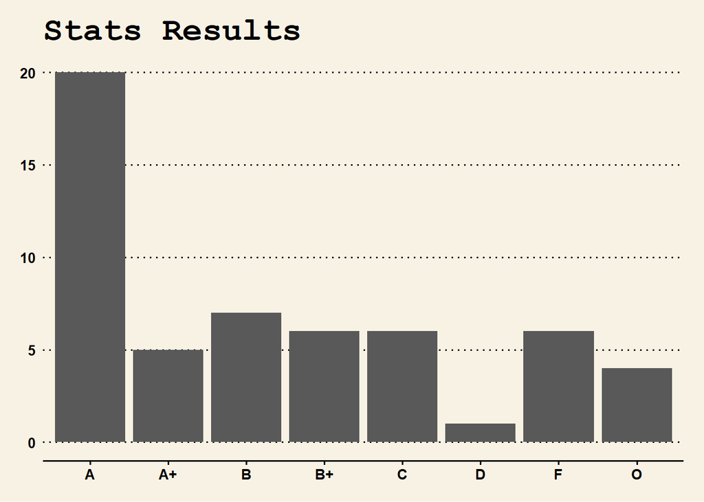

## DBMS Plot

Oh my God, this is a massive Improvement, for an IT subject we really scored well than our previous semesters, if you don’t believe compare and contrast between Python and DBMS and you will know yourselves.

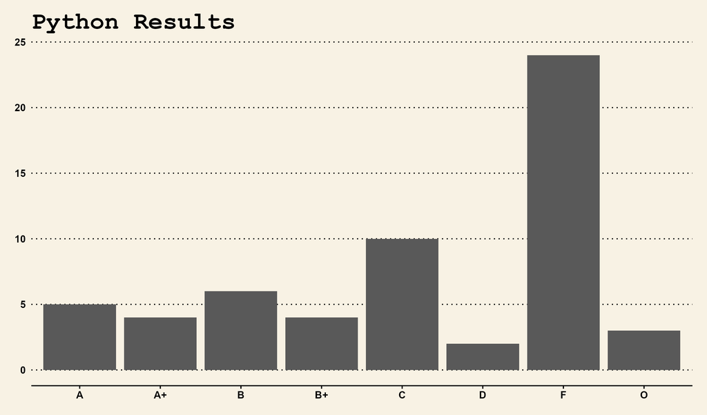

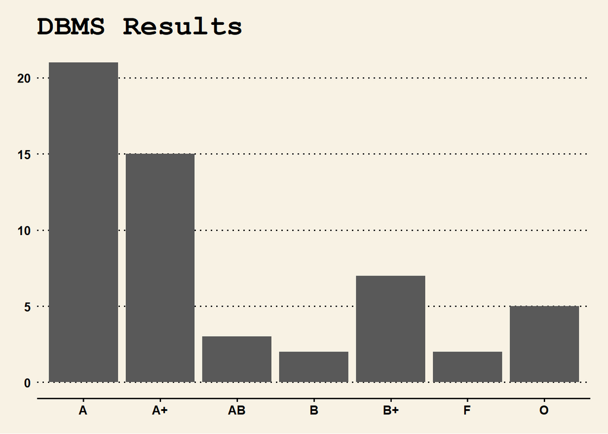

## UHVGS Plot

This was the most easiest subject out of all subjects and we can clearly see in the graph that majority of students have scored excellent grades in this subject but this time due to attendance many students were unable to write the exam.

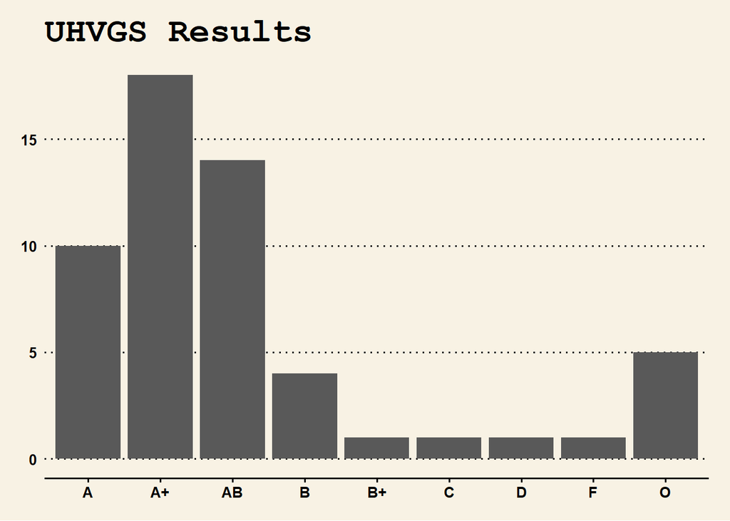

## Top 10 performing students

This semester the top 10 students performed are given below in the table where most of the students had a tough time, these students passed with an exceptional grade. This time both Gurpreet and Rahim scored the best marks. Congratulations to them!

| student.name | program | hall_ticket_number | semester_details | PHRM | LAB | CMA | Statistics | DBMS | UHVGS | SGPA | Result |
| --- | --- | --- | --- | --- | --- | --- | --- | --- | --- | --- | --- |
| SARDARNI GURUPREET KAUR | BBA INFORMATION TECHNOLOGY | 121423408001 | SEMESTER-III(REGULAR) | A+ | O | A+ | O | O | O | 9.63 | PASS |
| DOSANI RAHIM | BBA INFORMATION TECHNOLOGY | 121423408029 | SEMESTER-III(REGULAR) | A+ | O | A+ | O | O | O | 9.63 | PASS |
| RETIWALE NEHA SINGH | BBA INFORMATION TECHNOLOGY | 121423408012 | SEMESTER-III(REGULAR) | A+ | A+ | A+ | A+ | O | O | 9.26 | PASS |
| KOTA GIRI VARSHA | BBA INFORMATION TECHNOLOGY | 121423408026 | SEMESTER-III(REGULAR) | A+ | A+ | A+ | O | A+ | A+ | 9.19 | PASS |
| K VYSHNAVI | BBA INFORMATION TECHNOLOGY | 121423408008 | SEMESTER-III(REGULAR) | A | A | A+ | A+ | O | A+ | 8.81 | PASS |
| MARYAM BAIG | BBA INFORMATION TECHNOLOGY | 121423408041 | SEMESTER-III(REGULAR) | A | A+ | A+ | A+ | A+ | A+ | 8.81 | PASS |
| PIYUSH JAIN | BBA INFORMATION TECHNOLOGY | 121423408006 | SEMESTER-III(REGULAR) | A | B | A+ | O | O | O | 8.70 | PASS |
| DASHRATH DINESH SAI SACHIN | BBA INFORMATION TECHNOLOGY | 121423408039 | SEMESTER-III(REGULAR) | A+ | A | A | A | A+ | A+ | 8.44 | PASS |
| CHITUKULA AKANKSHA | BBA INFORMATION TECHNOLOGY | 121423408013 | SEMESTER-III(REGULAR) | A | A | A | A | A+ | O | 8.33 | PASS |
| MAYANK GUPTA | BBA INFORMATION TECHNOLOGY | 121423408005 | SEMESTER-III(REGULAR) | A | A | A | A | A+ | A+ | 8.26 | PASS |